# MATH 3070 Lab Project 13

Aini Liang

07 十二月, 2017

*Remember: I expect to see commentary either in the text, in the code with comments created using `#`, or (preferably) both! **Failing to do so may result in lost points!***

## Problem 1 (Verzani problem 9.14)

*The data set `normtemp` (**UsingR**) contains measurements of 130 healthy, randomly selected individuals. The variable `temperature` contains normal body temperature. Does the data appear to come from a Normal distribution? If so, perform a $t$-test to see if the commonly assumed value of 98.6 degrees fahrenheit is correct. (Studies have suggested that 98.2 degrees fahrenheit is more accurate.)*

```r
# Your code here
library(UsingR)
```

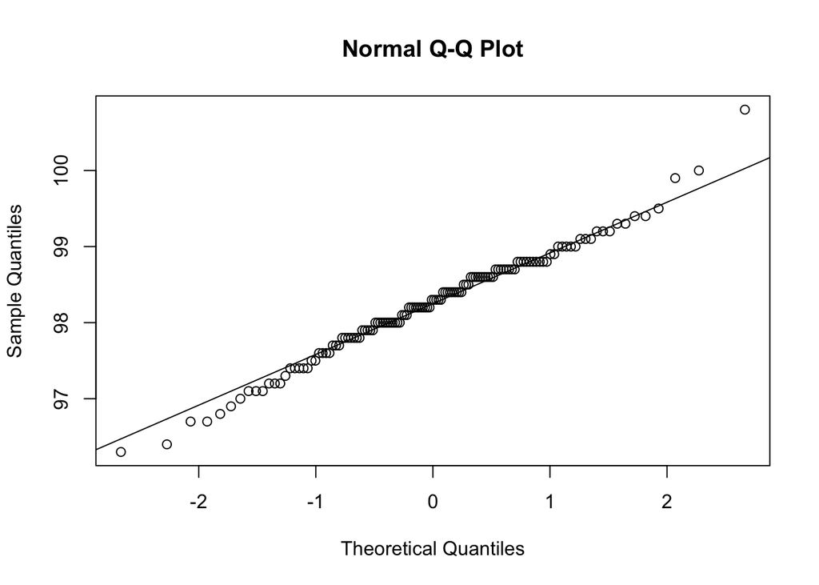

```r
qqnorm(normtemp$temperature)
qqline(normtemp$temperature)
```

```r
t.test(normtemp$temperature, mu = 98.6)
```

```
##
##  One Sample t-test
##
## data:  normtemp$temperature
## t = -5.4548, df = 129, p-value = 2.411e-07
## alternative hypothesis: true mean is not equal to 98.6
## 95 percent confidence interval:
##  98.12200 98.37646
## sample estimates:
## mean of x
##  98.24923
```

## Problem 2 (Verzani problem 9.4)

*In the United States in 2007, the proportion of adults age 21-24 who had no medical insurance was 28.1 percent. A survey of 75 recent college graduates in this age range finds that 40 percent are without insurance. Does this support a difference from the nationwide proportion? Perform a test of significance and report the p-value. Is it significant? (Perform this test “by hand”, not using `prop.test()`.)*

```r
# Your code here

n <- 75
pn <- 0.281
ph <- 0.4
a <- (ph - pn)/(sqrt(pn * (1 - pn)/n))
pval <- 2 * (1 - pnorm(abs(a)))
pval
```

```
## [1] 0.0218614
```

## Problem 3 (Verzani problem 9.16)

*A one-sided, one-sample $t$-test will be performed. What sample size is needed to have a power of 0.80 for a significance level of 0.05 if `delta = 0.05` and the population standard deviation is assumed to be 5?*

```r
# Your code here
power.t.test(power = 0.8, delta = 0.05, sd = 5, sig.level = 0.05, type = "one.sample",
    alternative = "one.sided")
```

```
##
##      One-sample t test power calculation
##
##               n = 61826.93
##           delta = 0.05
##              sd = 5
##       sig.level = 0.05
##           power = 0.8
##     alternative = one.sided
```

## Problem 4 (Verzani problem 9.31)

*For the `babies` (**UsingR**) data set, the variable `age` contains the recorded mom’s age and `dage` contains the dad’s age for several cases in the sample. Do a significance test of the null hypothesis of equal ages against a one-sided alternative that the dads are older in the sampled population.*

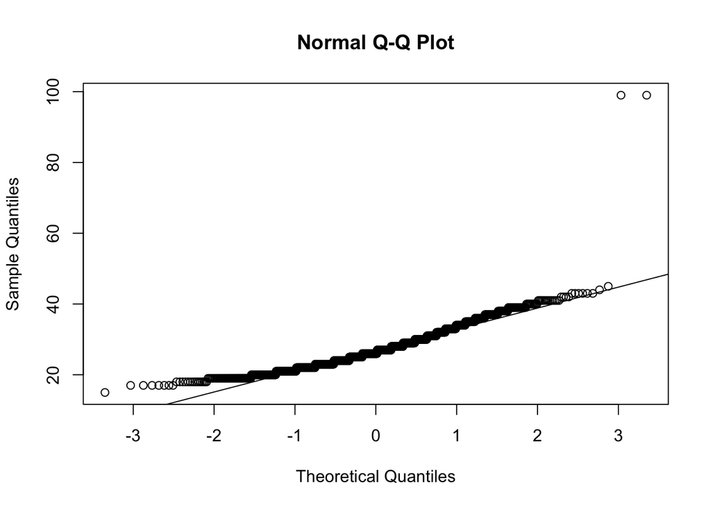

```r
# Your code here
qqnorm(babies$age)
qqline(babies$age)
```

```r
t.test(babies$age, babies$age, alternative = "greater", paired = TRUE)
```

```
##
##  Paired t-test
##
## data:  babies$age and babies$age
## t = NaN, df = 1235, p-value = NA
## alternative hypothesis: true difference in means is greater than 0
## 95 percent confidence interval:
##  NaN NaN
## sample estimates:
## mean of the differences
##                       0
```